# Wine Exploratory Data Analysis

Paul Mello

10/19/21

## Introduction

I have selected this data set because I am interested in learning about which properties have a significant impact on the quality of a wine. I have begun researching the world of wines recently and this variety comes from the north of Portugal. As a descendant of two Portuguese immigrants, I thought it would be a great data set to work with. I hope that once my analysis is finished I will have deciphered what makes a quality wine.

## Data

Data source: https://archive.ics.uci.edu/ml/datasets/Wine+Quality

Data collection: This data set is a collection of wine data sampled from the northern end of Portugal by Paulo Cortez in 2009. Specifically, it comes from a variety of grapes called “Vinho Verde”. Cortez collected these samples as part of an observational study “to model wine quality based on physicochemical tests.”

Units of observations:

Each row represents a purchasable wine. The wine name, price, and other identifying aspects have been removed for privacy reasons.

The column names are denoted below with a brief summary describing the unit of observation.

1. fixed acidity - Ratio (double), 4 Types of acids found in wine.
2. volatile acidity - Ratio (double), Measure of a wines gaseous acid content.
3. citric acid - Ratio (double), Measure of wines citric acid content.
4. residual sugar - Ratio (double), Measure of natural grape sugar leftovers after fermentation.
5. chlorides - Interval (double), Measures the saltiness of a wine. Consistent with the salt in water used during the wine making process.
6. free sulfur dioxide - Ratio (integer), Helps with bacterial stability, should be used early before fermentation process. (free refers to remaining sulphates to fight bacteria)
7. total sulfur dioxide - Ratio (integer), A total of free sulfur dioxide plus the other portions of SO2 already present in the wine. (total refers to all sulphates present)
8. density - Ratio (double), A Measure of how dense the wine is.
9. pH - Interval (double), A measure of how acidic or basic the water is. x < 7 = acidic, x > 7 = basic.
10. sulfates - Ratio (double), The sulfate content of the wine.
11. alcohol - Ratio (double), The alcohol content of the wine.
12. quality - Ordinal (integer), The overall quality of the wine evaluated by 3 wine experts.

Additional derived columns will be added to each data set consisting of the following descriptions:

13. total.free - Ratio (double), total sulfur dioxide - free sulfur dioxide.
20. color - Nominal (string), color of observed wine. *Only found in the aggregate wine data set.

Variables: I plan to study the wine data set by using all of the variables given. Although, I will need to clean up certain aspects of the data set.

## Questions

Important Concepts:

Wines are made in a process composed of many parts over potentially very long time periods of time.

They have diminishing returns in each attribute column. For example drinking pure sulfates would be toxic not tasty. Additionally, quality is a subjective measure, even by professionals.

1. Is there a strong correlation between total/free sulfur and the quality of a wine?
2. Which aspects of acidity play an important role?
3. Is the quality of a wine valid?
4. Can wine color be determined by physiochemical properties?

```r
# install.packages("caret")
```

```r
library(tidyverse)
library(ggplot2)
library(caret)
```

```r
set.seed(101)
```

## Data Preprocessing

Loading and formatting data.

```r
redWine <- read.csv(url("https://archive.ics.uci.edu/ml/machine-learning-databases/wine-quality/winequality-red.csv"), sep=";")
whiteWine <- read.csv(url("https://archive.ics.uci.edu/ml/machine-learning-databases/wine-quality/winequality-white.csv"), sep=";")
```

Adding derived columns and creating a new aggregated data set. The new column being created represent the quantity of the current “dead” sulfates that are no longer actively fighting bacterial growth.

```r
redWine$total.free <- (redWine$total.sulfur.dioxide - redWine$free.sulfur.dioxide)

whiteWine$total.free <- (whiteWine$total.sulfur.dioxide - whiteWine$free.sulfur.dioxide)

redWine$color <- ("Red")

whiteWine$color <- ("White")

Wine <- rbind(redWine, whiteWine)

Wine$quality <- as.numeric(Wine$quality)

redWine <- redWine %>% select(-color)
whiteWine <- whiteWine %>% select(-color)
```

## Data Checks and Cleanup:

```
## [1] "Missing Values of Red Wine: 0"
```

```
## [1] "Missing Values of White Wine: 0"
```

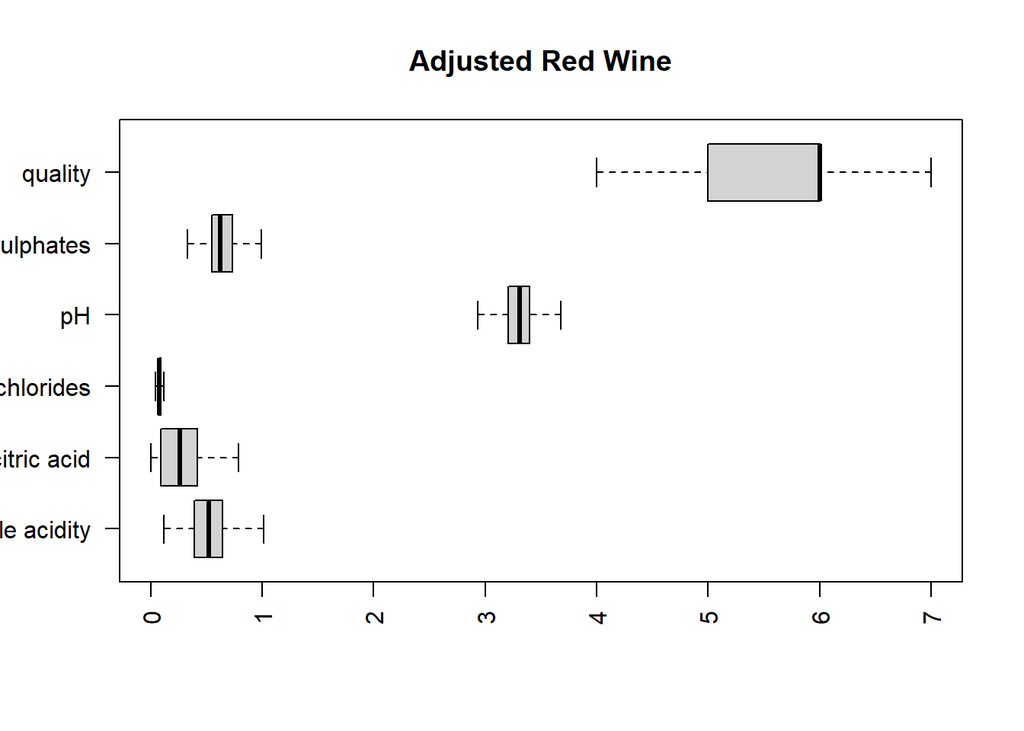

```r
boxplot(tempRed, main = "Adjusted Red Wine", outline = FALSE, names = c("volatile acidity"," citric acid", "chlorides", "pH", "sulphates", "quality"), horizontal = TRUE, las = 2)
```

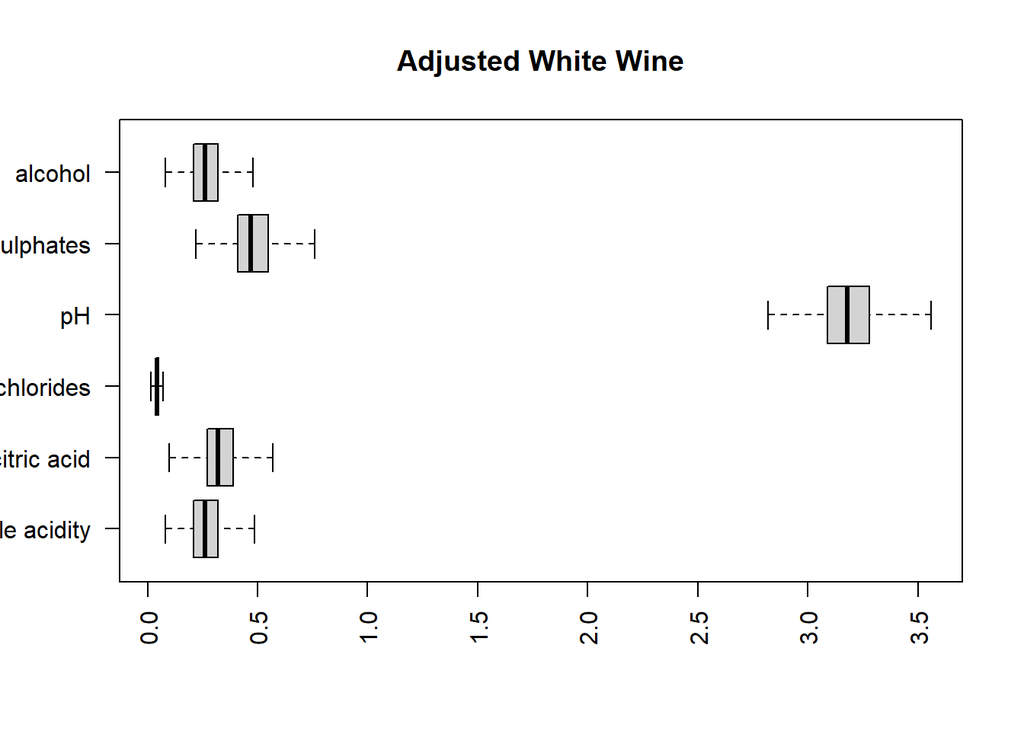

```r
boxplot(tempWhite, main = "Adjusted White Wine", outline=FALSE, names = c("volatile acidity"," citric acid", "chlorides", "pH", "sulphates", "alcohol"), horizontal  =TRUE, las = 2)
```

```r
redOutliers <- as.integer(count(redWineOutliers))
whiteOutliers <- as.integer(count(whiteWineOutliers))

sprintf("Number of Outliers In Red Wine Data: %i", redOutliers)
```

```
## [1] "Number of Outliers In Red Wine Data: 465"
```

```r
sprintf("Number of Outliers In White Wine Data: %i", whiteOutliers)
```

```
## [1] "Number of Outliers In White Wine Data: 1068"
```

As it turns out, there are a significant amount of outliers throughout both data sets. I have decided not to remove most outliers because I believe many of the outliers are simply an aspect of the wine as opposed to a true outlier. This may affect the PCA analysis later. Despite this conclusion I have removed some of the most egregious outliers because they were many times outside the range of their respective properties.

## Exploratory Data Analysis

Here we can see an aggregated summary of the wine data. This gives us some meaningful insights regarding the analysis of the data.

```
##  fixed.acidity   volatile.acidity  citric.acid     residual.sugar
##  Min.   : 4.60   Min.   :0.1200   Min.   :0.0000   Min.   : 0.900
##  1st Qu.: 7.10   1st Qu.:0.3900   1st Qu.:0.0900   1st Qu.: 1.900
##  Median : 7.90   Median :0.5200   Median :0.2600   Median : 2.200
##  Mean   : 8.32   Mean   :0.5281   Mean   :0.2705   Mean   : 2.532
##  3rd Qu.: 9.20   3rd Qu.:0.6400   3rd Qu.:0.4200   3rd Qu.: 2.600
##  Max.   :15.90   Max.   :1.5800   Max.   :1.0000   Max.   :15.500
##    chlorides       free.sulfur.dioxide total.sulfur.dioxide       pH
##  Min.   :0.01200   Min.   : 1.00       Min.   :  6.00       Min.   :2.740
##  1st Qu.:0.07000   1st Qu.: 7.00       1st Qu.: 22.00       1st Qu.:3.210
##  Median :0.07900   Median :14.00       Median : 38.00       Median :3.310
##  Mean   :0.08751   Mean   :15.85       Mean   : 46.17       Mean   :3.311
##  3rd Qu.:0.09000   3rd Qu.:21.00       3rd Qu.: 62.00       3rd Qu.:3.400
##  Max.   :0.61100   Max.   :72.00       Max.   :165.00       Max.   :4.010
##    sulphates         alcohol         quality        total.free
##  Min.   :0.3300   Min.   : 8.40   Min.   :3.000   Min.   :  3.00
##  1st Qu.:0.5500   1st Qu.: 9.50   1st Qu.:5.000   1st Qu.: 12.00
##  Median :0.6200   Median :10.20   Median :6.000   Median : 21.00
##  Mean   :0.6583   Mean   :10.42   Mean   :5.634   Mean   : 30.32
##  3rd Qu.:0.7300   3rd Qu.:11.10   3rd Qu.:6.000   3rd Qu.: 39.00
##  Max.   :2.0000   Max.   :14.90   Max.   :8.000   Max.   :128.00
```

```
##  fixed.acidity    volatile.acidity  citric.acid     residual.sugar
##  Min.   : 3.800   Min.   :0.0800   Min.   :0.0000   Min.   : 0.600
##  1st Qu.: 6.300   1st Qu.:0.2100   1st Qu.:0.2700   1st Qu.: 1.700
##  Median : 6.800   Median :0.2600   Median :0.3200   Median : 5.200
##  Mean   : 6.854   Mean   :0.2781   Mean   :0.3342   Mean   : 6.393
##  3rd Qu.: 7.300   3rd Qu.:0.3200   3rd Qu.:0.3900   3rd Qu.: 9.900
##  Max.   :14.200   Max.   :1.1000   Max.   :1.6600   Max.   :65.800
##    chlorides       free.sulfur.dioxide total.sulfur.dioxide       pH
##  Min.   :0.00900   Min.   :  2.00      Min.   :  9.0        Min.   :2.720
##  1st Qu.:0.03600   1st Qu.: 23.00      1st Qu.:108.0        1st Qu.:3.090
##  Median :0.04300   Median : 34.00      Median :134.0        Median :3.180
##  Mean   :0.04577   Mean   : 35.21      Mean   :138.1        Mean   :3.188
##  3rd Qu.:0.05000   3rd Qu.: 46.00      3rd Qu.:167.0        3rd Qu.:3.280
##  Max.   :0.34600   Max.   :131.00      Max.   :313.0        Max.   :3.820
##    sulphates         alcohol          quality       total.free
##  Min.   :0.2200   Min.   :0.0800   Min.   :3.00   Min.   :  4.0
##  1st Qu.:0.4100   1st Qu.:0.2100   1st Qu.:5.00   1st Qu.: 78.0
##  Median :0.4700   Median :0.2600   Median :6.00   Median :100.0
##  Mean   :0.4898   Mean   :0.2781   Mean   :5.88   Mean   :102.9
##  3rd Qu.:0.5500   3rd Qu.:0.3200   3rd Qu.:6.00   3rd Qu.:125.0
##  Max.   :1.0800   Max.   :1.1000   Max.   :9.00   Max.   :243.0
```

```r
summary(Wine) #Aggregate Wine Data
```

```
##  fixed.acidity    volatile.acidity  citric.acid     residual.sugar
##  Min.   : 3.800   Min.   :0.0800   Min.   :0.0000   Min.   : 0.600
##  1st Qu.: 6.400   1st Qu.:0.2300   1st Qu.:0.2500   1st Qu.: 1.800
##  Median : 7.000   Median :0.2900   Median :0.3100   Median : 3.000
##  Mean   : 7.215   Mean   :0.3396   Mean   :0.3187   Mean   : 5.444
##  3rd Qu.: 7.700   3rd Qu.:0.4000   3rd Qu.:0.3900   3rd Qu.: 8.100
##  Max.   :15.900   Max.   :1.5800   Max.   :1.6600   Max.   :65.800
##    chlorides       free.sulfur.dioxide total.sulfur.dioxide       pH
##  Min.   :0.00900   Min.   :  1.00      Min.   :  6.0        Min.   :2.720
##  1st Qu.:0.03800   1st Qu.: 17.00      1st Qu.: 77.0        1st Qu.:3.110
##  Median :0.04700   Median : 29.00      Median :118.0        Median :3.210
##  Mean   :0.05604   Mean   : 30.43      Mean   :115.5        Mean   :3.218
##  3rd Qu.:0.06500   3rd Qu.: 41.00      3rd Qu.:156.0        3rd Qu.:3.320
##  Max.   :0.61100   Max.   :128.00      Max.   :303.0        Max.   :4.010
##    sulphates         alcohol         quality       total.free
##  Min.   :0.2200   Min.   : 8.00   Min.   :3.00   Min.   :  3.00
##  1st Qu.:0.4300   1st Qu.: 9.50   1st Qu.:5.00   1st Qu.: 55.00
##  Median :0.5100   Median :10.30   Median :6.00   Median : 86.00
##  Mean   :0.5312   Mean   :10.49   Mean   :5.82   Mean   : 85.11
##  3rd Qu.:0.6000   3rd Qu.:11.30   3rd Qu.:6.00   3rd Qu.:116.00
##  Max.   :2.0000   Max.   :14.90   Max.   :9.00   Max.   :251.50
##     color
##  Length:6491
##  Class :character
##  Mode  :character
##
##
##
```

The following graphic will provide us with an understanding of the distribution of wine quality given the type of wine. It is also important to remember that the white wine data set contains approximately 3x as many variables as red wine.

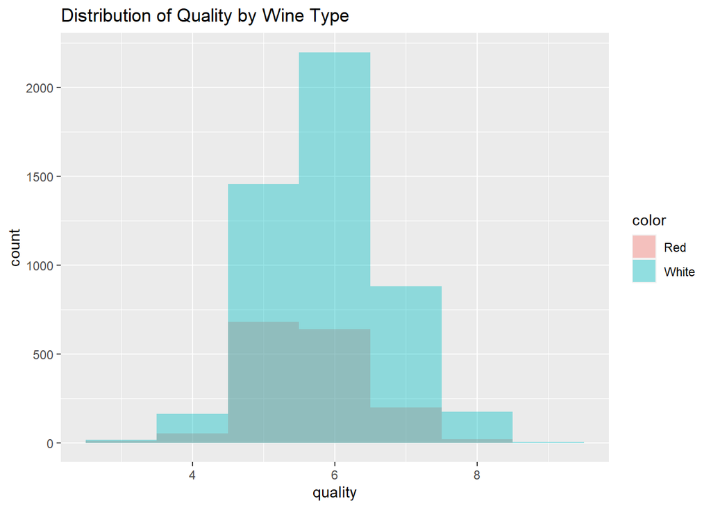

```r
ggplot(Wine, aes(x = quality, fill = color)) +
  labs(title = "Distribution of Quality by Wine Type") +
  geom_histogram(alpha = 0.4, position = "identity",  binwidth = 1)
```

One question that could be asked is why are there differences in the quality distribution between both data sets? One proposal is that the variety of grapes being used, along with other external factors, may contribute to a higher quality white wine than a red wine.

### Question 1

#### Sulfates as an important factor in the quality of a wine

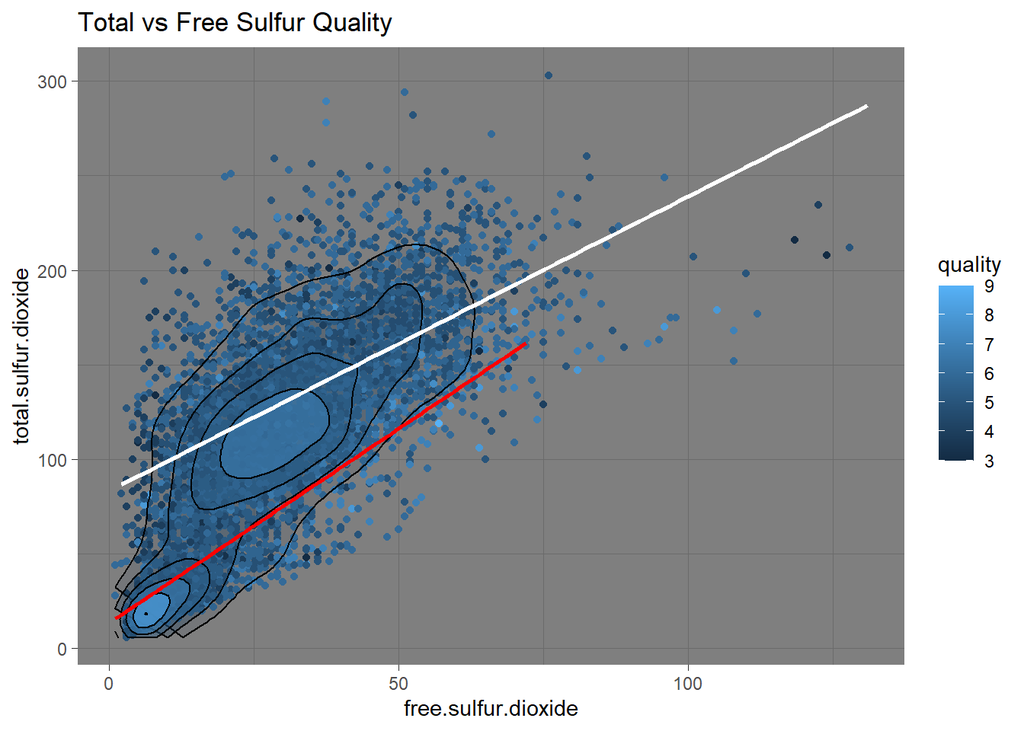

```r
ggplot(Wine, aes(x = free.sulfur.dioxide, y = total.sulfur.dioxide)) +
   theme_dark() +
   geom_point(aes(color = quality)) +
   labs(title = "Total vs Free Sulfur Quality") +
   stat_density_2d(aes(fill = ..level.., alpha = ..level..), geom = 'polygon', color = "black", countour_var = "quality",  show.legend = FALSE) +
   geom_smooth(data = redWine, method = lm, se = FALSE, col = "red") +
   geom_smooth(data = whiteWine, method = lm, se = FALSE, col = "white")
```

As demonstrated in the graph above there is an interesting relationship between the sulfur contents and quality. There is a “sweet spot”, around (10,10) and (30, 110), these tend to demonstrate a higher quality wine. This appears when a balance between total and free sulfur is evident. Outside of this sweet spot, quality varies widely. As total sulfur dioxide increases we tend to see lower quality wines. This was unexpected, but makes sense as too much sulfur can mean a wine does not grow, while too little sulfur may indicate too much growth. Here my reference to growth entails that the wine continues to evolve flavors while in the bottle.

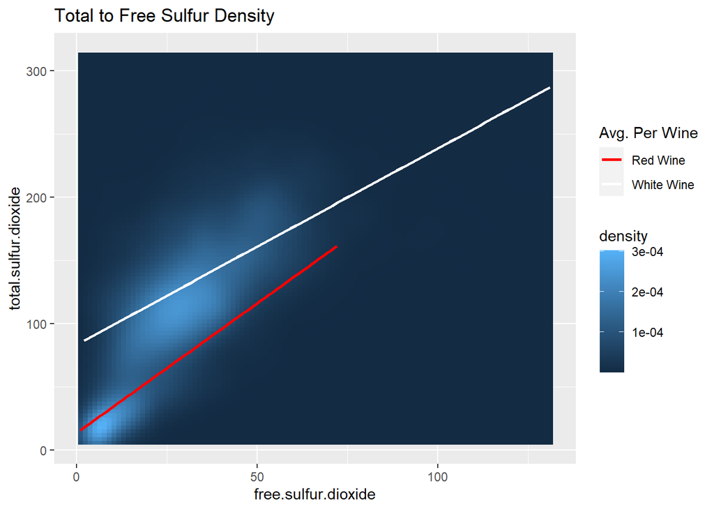

```r
ggplot(Wine, aes(x = free.sulfur.dioxide, y = total.sulfur.dioxide) ) +
   labs(title = "Total to Free Sulfur Density") +
   stat_density_2d(aes(fill = ..density..), geom = "raster", contour = FALSE)  +
   geom_smooth(data = redWine, method = lm, se = FALSE, aes(col = "red")) +
   geom_smooth(data = whiteWine, method = lm, se = FALSE, aes(col = "white"))+
   scale_colour_manual(name = "Avg. Per Wine", values = c("Red", "White"), labels = c("Red Wine", "White Wine"))
```

The graph above demonstrates the density of the wine data points given total and free sulfur.

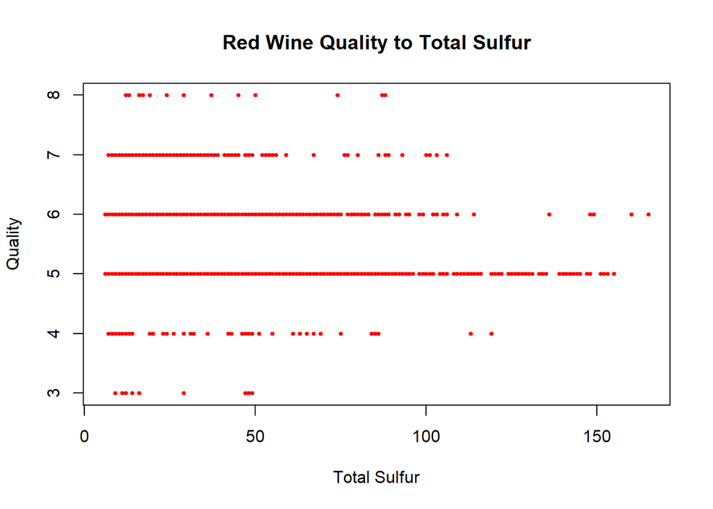

```r
plot(redWine$total.sulfur.dioxide, redWine$quality, col = 'red', pch = 19, cex = .5, xlab = 'Total Sulfur', ylab = 'Quality', main = 'Red Wine Quality to Total Sulfur')
```

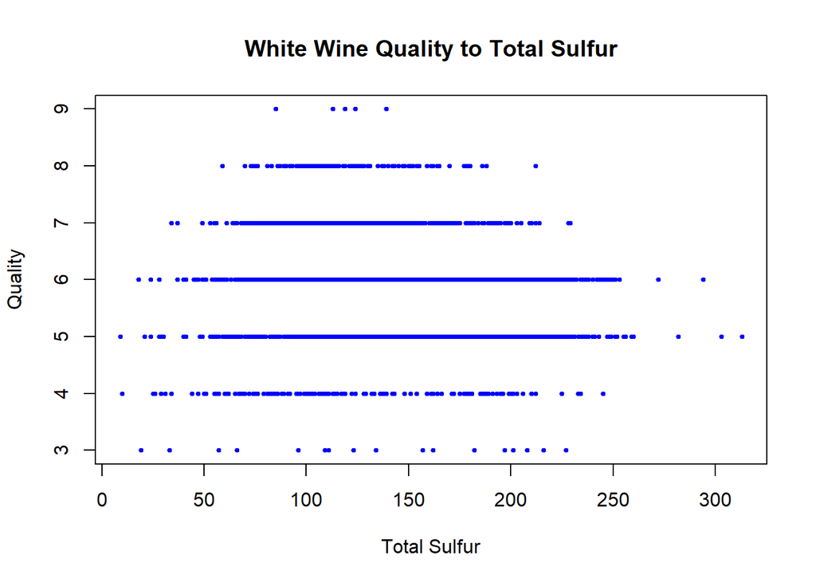

```r
plot(whiteWine$total.sulfur.dioxide, whiteWine$quality, col = 'Blue', pch = 19, cex = .5, xlab = 'Total Sulfur', ylab = 'Quality', main = 'White Wine Quality to Total Sulfur')
```

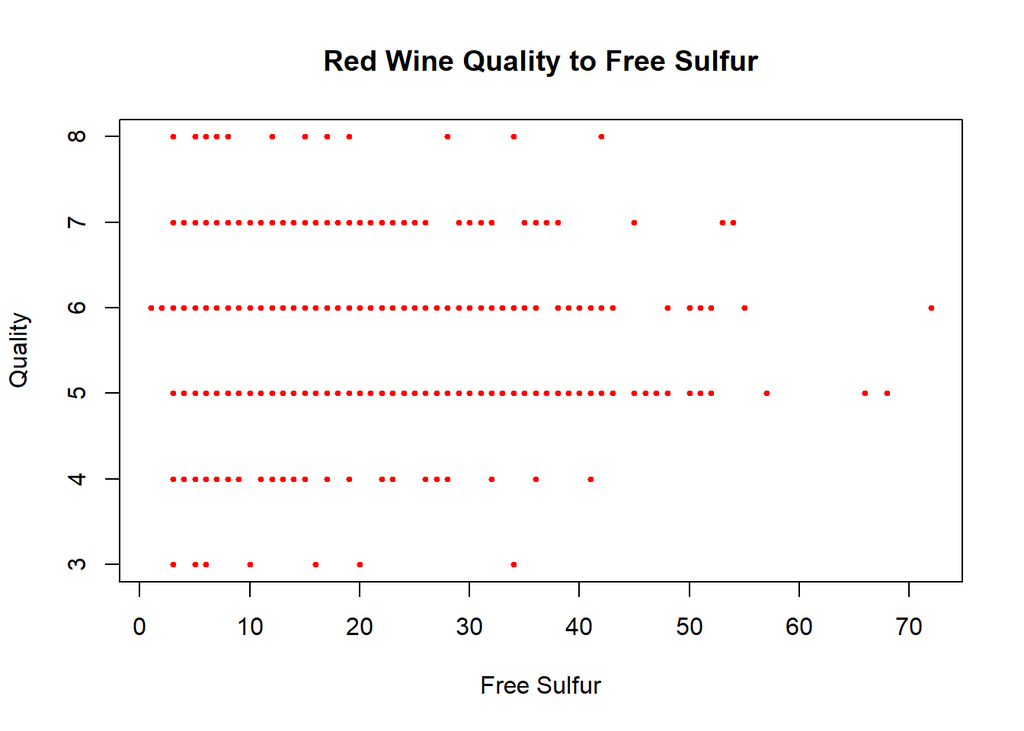

```r
plot(redWine$free.sulfur.dioxide, redWine$quality, col = 'Red', pch = 19, cex = .5, xlab = 'Free Sulfur', ylab = 'Quality', main = 'Red Wine Quality to Free Sulfur')
```

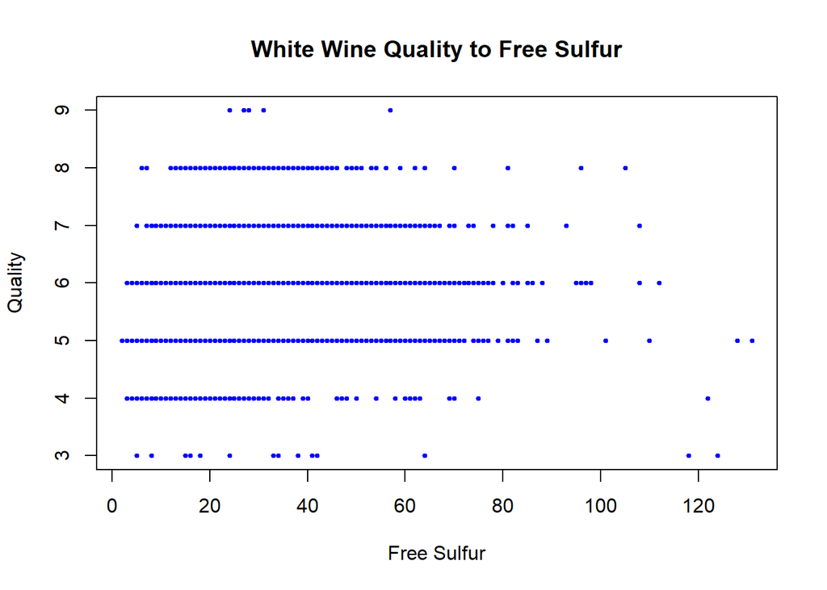

```r
plot(whiteWine$free.sulfur.dioxide, whiteWine$quality, col = 'Blue', pch = 19, cex = .5, xlab = 'Free Sulfur', ylab = 'Quality', main = 'White Wine Quality to Free Sulfur')
```

As we can see by the distribution graphs above, there are a few prevalent patterns. In the Total Sulfur graphs, we can see that there are distinct differences between each wine group leading to the conclusion that Total Sulfur is playing a role in the quality of the wine. Further differences also appear when considering the type of wine. Additionally, when addressing Free Sulfur we can see that there is very little variation even between the wine types.

Below I demonstrate the aggregatged distributions of total and free sulfur.

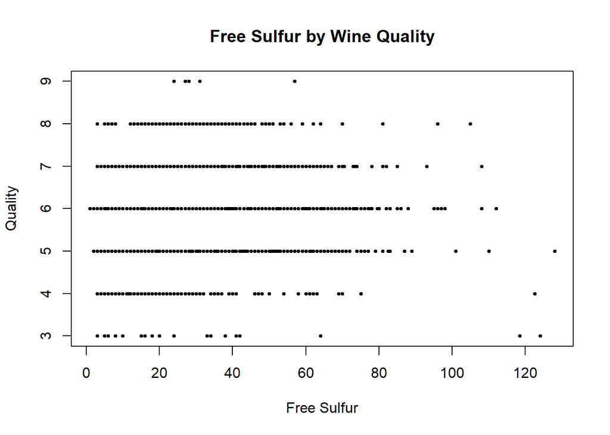

```r
plot(Wine$free.sulfur.dioxide, Wine$quality, col = 'Black', pch = 19, cex = .5, xlab = 'Free Sulfur', ylab = 'Quality', main = 'Free Sulfur by Wine Quality')
```

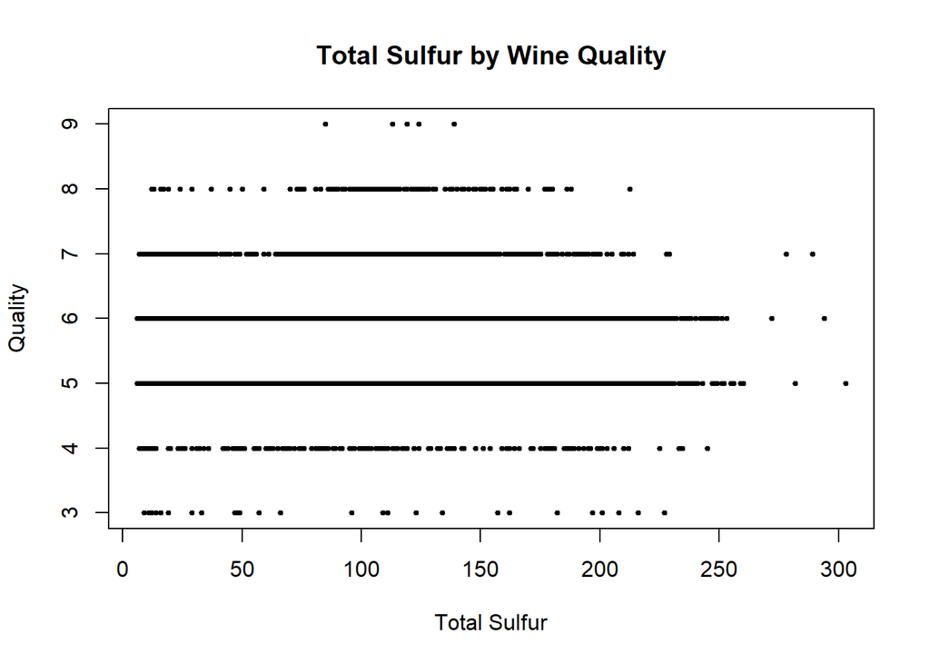

```r
plot(Wine$total.sulfur.dioxide, Wine$quality, col = 'Black', pch = 19, cex = .5, xlab = 'Total Sulfur', ylab = 'Quality', main = 'Total Sulfur by Wine Quality')
```

We can see that there are specific concentrations of an allowed variation from the mean in each respective plot that can help identify a better quality wine.

To conclude this question there appears to be a relation between the sulfates and quality of a wine. Even if we can not identify the exact pattern we can see the trends of what makes a good quality wine.

### Question 2

#### Which aspects of acidity play an important role?

After preparing our respective datasets it is now time to determine the percentages of our checks.

```
## [1] 0.983785546 0.012579105 0.003635349
```

```
## [1] 0.66898046 0.24978958 0.08122996
```

```
## [1] 0.96800118 0.01923637 0.01276245
```

```
## [1] 0.4452964 0.3267185 0.2279851
```

```r
WCV.percent
```

```
## [1] 0.974148960 0.019462100 0.006388941
```

```r
WCR.percent
```

```
## [1] 0.4679874 0.4049186 0.1270940
```

checking the sum values to ensure our data is still valid

```
## [1] 0.9837855 0.9963647 1.0000000
```

```
## [1] 0.6689805 0.9187700 1.0000000
```

```
## [1] 0.9680012 0.9872376 1.0000000
```

```
## [1] 0.4452964 0.7720149 1.0000000
```

```
## [1] 0.9741490 0.9936111 1.0000000
```

```
## [1] 0.4679874 0.8729060 1.0000000
```

After the initial developments its clear that columns 1 and 2 have the highest impact. These are consistent of fixed.acidity and volatile.acidity

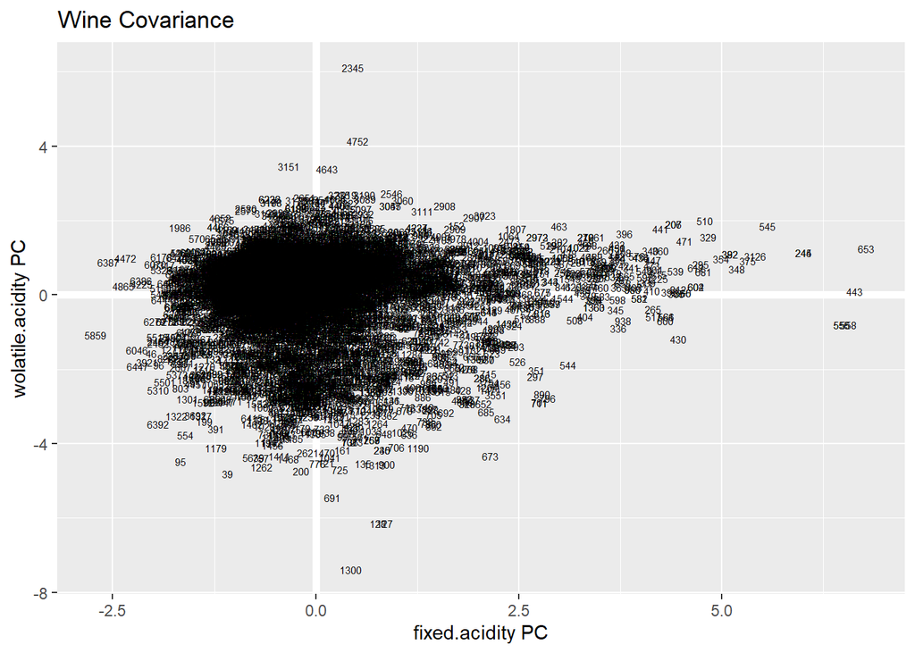

```r
ggplot(W.CV.PCS, aes(w.V.PC1, w.V.PC2)) +
    modelr::geom_ref_line(h = 0) +
    modelr::geom_ref_line(v = 0) +
    geom_text(aes(label = WCOV.index), size = 2) +
    xlab("fixed.acidity PC") +
    ylab("wolatile.acidity PC") +
    ggtitle("Wine Covariance")
```

```r
W.CV.PCS
```

|  | WCOV.index | w.V.PC1 | w.V.PC2 |
| --- | --- | --- | --- |
| 1 | 1 | 1.235059e-01 | -3.059486862 |
| 2 | 2 | 4.622488e-01 | -3.942373996 |
| 3 | 3 | 4.519322e-01 | -3.191450126 |
| 4 | 4 | 3.120724e+00 | 1.274051405 |
| 5 | 5 | 1.235059e-01 | -3.059486862 |
| 6 | 6 | 1.167142e-01 | -2.863217363 |
| 7 | 7 | 5.068396e-01 | -2.325233041 |
| 8 | 8 | 3.797122e-02 | -2.814231391 |
| 9 | 9 | 4.163400e-01 | -2.389295066 |
| 10 | 10 | 2.571198e-01 | -0.619019615 |

[output cut: 6481 more lines]

```r
eigenWCV
```

```
## eigen() decomposition
## $values
## [1] 1.68463132 0.03365652 0.01104863
##
## $vectors
##            [,1]         [,2]        [,3]
## [1,] 0.99894038  0.001055446  0.04601091
## [2,] 0.02796036 -0.808005488 -0.58851113
## [3,] 0.03655592  0.589174013 -0.80717882
```

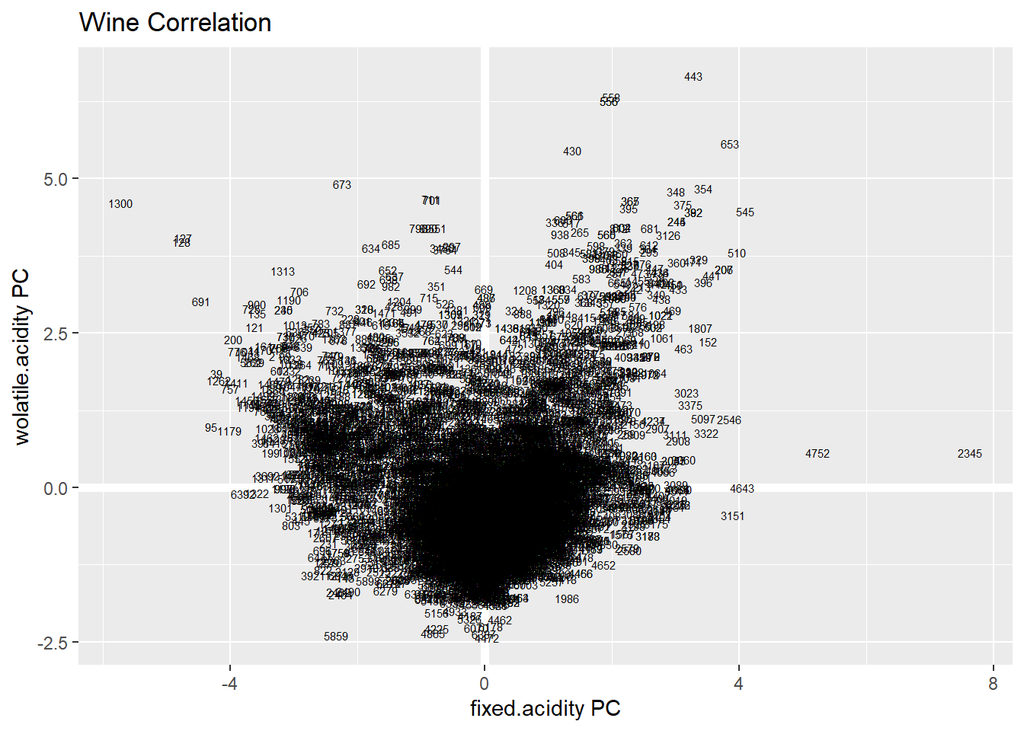

```r
ggplot(W.CR.PCS, aes(w.R.PC1, w.R.PC2)) +
    modelr::geom_ref_line(h = 0) +
    modelr::geom_ref_line(v = 0) +
    geom_text(aes(label = WCOR.index), size = 2) +
    xlab("fixed.acidity PC") +
    ylab("wolatile.acidity PC") +
    ggtitle("Wine Correlation")
```

```r
W.CR.PCS
```

|  | WCOR.index | w.R.PC1 | w.R.PC2 |
| --- | --- | --- | --- |
| 1 | 1 | -2.8440663110 | 1.2185672739 |
| 2 | 2 | -3.3428542237 | 2.1292983671 |
| 3 | 3 | -2.7314800718 | 1.7125070908 |
| 4 | 4 | 2.4728587249 | 2.3630753264 |
| 5 | 5 | -2.8440663110 | 1.2185672739 |
| 6 | 6 | -2.7110732372 | 1.0699130991 |
| 7 | 7 | -2.0683900816 | 1.1929228427 |
| 8 | 8 | -2.7027451986 | 0.9723027287 |
| 9 | 9 | -2.2392087050 | 1.0289776807 |
| 10 | 10 | -0.2426263375 | 0.7982844577 |

[output cut: 6481 more lines]

```r
eigenWCR
```

```
## eigen() decomposition
## $values
## [1] 1.4039622 1.2147558 0.3812819
##
## $vectors
##            [,1]      [,2]       [,3]
## [1,]  0.3231075 0.7837337  0.5304366
## [2,] -0.5475081 0.6119819 -0.5707127
## [3,]  0.7719044 0.1060167 -0.6268365
```

This PCA analysis has helped us see the components of acidity and how the two most important types of acidity which are the fixed and volatile acidity, have very similar characteristics. I believe this is in part due to the individual meanings of fixed and volatile. As a reminder fixed is representative of 4 types of acids and volatile represents the gaseous components of the acids. More graphs related to each wine color demonstrating tight clustering can be found in the Appendix section.

### Question 3

In this approach I will attempt to develop a learning model to determine if the quality is consistent given its physio-chemical properties.

```r
newWine <- Wine

newWine$color[newWine$color == "Red"] <- 0
newWine$color[newWine$color == "White"] <- 1

newWine$color <- as.numeric(newWine$color)

Data = sort(sample(nrow(newWine), nrow(newWine)*.7))
trainingData <- newWine[Data,]
testingData <- newWine[-Data,]
```

```r
str(newWine)
```

```
## 'data.frame':    6491 obs. of  13 variables:
##  $ fixed.acidity       : num  7.4 7.8 7.8 11.2 7.4 7.4 7.9 7.3 7.8 7.5 ...
##  $ volatile.acidity    : num  0.7 0.88 0.76 0.28 0.7 0.66 0.6 0.65 0.58 0.5 ...
##  $ citric.acid         : num  0 0 0.04 0.56 0 0 0.06 0 0.02 0.36 ...
##  $ residual.sugar      : num  1.9 2.6 2.3 1.9 1.9 1.8 1.6 1.2 2 6.1 ...
##  $ chlorides           : num  0.076 0.098 0.092 0.075 0.076 0.075 0.069 0.065 0.073 0.071 ...
##  $ free.sulfur.dioxide : num  11 25 15 17 11 13 15 15 9 17 ...
##  $ total.sulfur.dioxide: num  34 67 54 60 34 40 59 21 18 102 ...
##  $ pH                  : num  3.51 3.2 3.26 3.16 3.51 3.51 3.3 3.39 3.36 3.35 ...
##  $ sulphates           : num  0.56 0.68 0.65 0.58 0.56 0.56 0.46 0.47 0.57 0.8 ...
##  $ alcohol             : num  9.4 9.8 9.8 9.8 9.4 9.4 9.4 10 9.5 10.5 ...
##  $ quality             : num  5 5 5 6 5 5 5 7 7 5 ...
##  $ total.free          : num  23 42 39 43 23 27 44 6 9 85 ...
##  $ color               : num  0 0 0 0 0 0 0 0 0 0 ...
```

```r
aggregateWineModel <- lm(quality ~ fixed.acidity + volatile.acidity + citric.acid + residual.sugar + chlorides + free.sulfur.dioxide + total.sulfur.dioxide + sulphates + alcohol + color, data = trainingData) # All variables contributing

summary(aggregateWineModel)
```

```
##
## Call:
## lm(formula = quality ~ fixed.acidity + volatile.acidity + citric.acid +
##     residual.sugar + chlorides + free.sulfur.dioxide + total.sulfur.dioxide +
##     sulphates + alcohol + color, data = trainingData)
##
## Residuals:
##     Min      1Q  Median      3Q     Max
## -3.3015 -0.4671 -0.0413  0.4519  3.0973
##
## Coefficients:
##                        Estimate Std. Error t value Pr(>|t|)
## (Intercept)           2.6193693  0.1793061  14.608  < 2e-16 ***
## fixed.acidity         0.0025147  0.0115056   0.219  0.82700
## volatile.acidity     -1.6471070  0.0980793 -16.794  < 2e-16 ***
## citric.acid          -0.1336411  0.0972456  -1.374  0.16943
## residual.sugar        0.0224206  0.0028046   7.994 1.64e-15 ***
## chlorides            -1.1045846  0.4013492  -2.752  0.00594 **
## free.sulfur.dioxide   0.0070183  0.0009535   7.360 2.17e-13 ***
## total.sulfur.dioxide -0.0017127  0.0003906  -4.385 1.19e-05 ***
## sulphates             0.5575631  0.0878627   6.346 2.43e-10 ***
## alcohol               0.3396601  0.0111592  30.438  < 2e-16 ***
## color                -0.2067607  0.0539745  -3.831  0.00013 ***
## ---
## Signif. codes:  0 '***' 0.001 '**' 0.01 '*' 0.05 '.' 0.1 ' ' 1
##
## Residual standard error: 0.7402 on 4532 degrees of freedom
## Multiple R-squared:  0.2933, Adjusted R-squared:  0.2918
## F-statistic: 188.1 on 10 and 4532 DF,  p-value: < 2.2e-16
```

After summarizing the models we are now able to see the significant coefficients contributing to the quality of the wine. Unfortunately, much of the variation in our data is unexplained by our model as shown by our R-squared. This leads me to conclude the data does not explain enough of the variance and is thus incomplete when determining quality. Despite this, I will still attempt to see if I can make an accurate classifier.

```r
aggregateDecantedWineModel <- glm(quality ~ (free.sulfur.dioxide * total.sulfur.dioxide) + (sulphates * chlorides * alcohol * residual.sugar) + alcohol + residual.sugar, data = trainingData) # All variables contributing

summary(aggregateDecantedWineModel)
```

```
##
## Call:
## glm(formula = quality ~ (free.sulfur.dioxide * total.sulfur.dioxide) +
##     (sulphates * chlorides * alcohol * residual.sugar) + alcohol +
##     residual.sugar, data = trainingData)
##
## Deviance Residuals:
##     Min       1Q   Median       3Q      Max
## -3.3627  -0.4919  -0.0512   0.4704   3.0869
##
## Coefficients:
##                                              Estimate Std. Error t value
## (Intercept)                                 5.927e-01  9.890e-01   0.599
## free.sulfur.dioxide                         2.093e-02  2.047e-03  10.226
## total.sulfur.dioxide                        7.131e-04  4.440e-04   1.606
## sulphates                                   3.748e-01  1.734e+00   0.216
## chlorides                                   2.311e+01  1.697e+01   1.362
## alcohol                                     4.112e-01  9.705e-02   4.237
## residual.sugar                             -3.697e-01  1.974e-01  -1.873
## free.sulfur.dioxide:total.sulfur.dioxide   -8.555e-05  1.254e-05  -6.822
## sulphates:chlorides                        -1.554e+01  2.702e+01  -0.575
## sulphates:alcohol                           5.777e-02  1.741e-01   0.332
## chlorides:alcohol                          -2.457e+00  1.755e+00  -1.400
## sulphates:residual.sugar                    8.963e-01  3.963e-01   2.262
## chlorides:residual.sugar                    1.017e+01  3.324e+00   3.060
## alcohol:residual.sugar                      4.555e-02  1.983e-02   2.297
## sulphates:chlorides:alcohol                 1.628e+00  2.857e+00   0.570
## sulphates:chlorides:residual.sugar         -1.914e+01  6.323e+00  -3.028
## sulphates:alcohol:residual.sugar           -9.959e-02  4.070e-02  -2.447
## chlorides:alcohol:residual.sugar           -1.070e+00  3.395e-01  -3.151
## sulphates:chlorides:alcohol:residual.sugar  1.959e+00  6.589e-01   2.974
##                                            Pr(>|t|)
## (Intercept)                                 0.54901
## free.sulfur.dioxide                         < 2e-16 ***
## total.sulfur.dioxide                        0.10830
## sulphates                                   0.82891
## chlorides                                   0.17334
## alcohol                                    2.31e-05 ***
## residual.sugar                              0.06116 .
## free.sulfur.dioxide:total.sulfur.dioxide   1.02e-11 ***
## sulphates:chlorides                         0.56515
## sulphates:alcohol                           0.73998
## chlorides:alcohol                           0.16145
## sulphates:residual.sugar                    0.02377 *
## chlorides:residual.sugar                    0.00222 **
## alcohol:residual.sugar                      0.02167 *
## sulphates:chlorides:alcohol                 0.56884
## sulphates:chlorides:residual.sugar          0.00248 **
## sulphates:alcohol:residual.sugar            0.01444 *
## chlorides:alcohol:residual.sugar            0.00164 **
## sulphates:chlorides:alcohol:residual.sugar  0.00296 **
## ---
## Signif. codes:  0 '***' 0.001 '**' 0.01 '*' 0.05 '.' 0.1 ' ' 1
##
## (Dispersion parameter for gaussian family taken to be 0.5745876)
##
##     Null deviance: 3513.4  on 4542  degrees of freedom
## Residual deviance: 2599.4  on 4524  degrees of freedom
## AIC: 10396
##
## Number of Fisher Scoring iterations: 2
```

```r
prediction <- round(predict(aggregateDecantedWineModel, testingData, type = 'response'))
prediction <- as.factor(prediction)
testingQuality <- as.factor(testingData$quality)
confusionMatrix(data = prediction, reference = testingQuality)
```

```
## Confusion Matrix and Statistics
##
##           Reference
## Prediction   3   4   5   6   7   8   9
##          3   0   0   0   0   0   0   0
##          4   0   0   1   2   0   0   0
##          5   4  21 306 163  16   2   0
##          6   3  26 321 630 243  24   0
##          7   0   1   5  63  92  21   3
##          8   0   0   1   0   0   0   0
##          9   0   0   0   0   0   0   0
##
## Overall Statistics
##
##                Accuracy : 0.5277
##                  95% CI : (0.5053, 0.5501)
##     No Information Rate : 0.4405
##     P-Value [Acc > NIR] : 6.682e-15
##
##                   Kappa : 0.2325
##
##  Mcnemar's Test P-Value : NA
##
## Statistics by Class:
##
##                      Class: 3 Class: 4 Class: 5 Class: 6 Class: 7  Class: 8
## Sensitivity          0.000000  0.00000   0.4826   0.7343  0.26211 0.0000000
## Specificity          1.000000  0.99842   0.8432   0.4339  0.94177 0.9994740
## Pos Pred Value            NaN  0.00000   0.5977   0.5052  0.49730 0.0000000
## Neg Pred Value       0.996407  0.97532   0.7716   0.6748  0.85309 0.9758603
## Prevalence           0.003593  0.02464   0.3255   0.4405  0.18018 0.0241273
## Detection Rate       0.000000  0.00000   0.1571   0.3234  0.04723 0.0000000
## Detection Prevalence 0.000000  0.00154   0.2628   0.6401  0.09497 0.0005133
## Balanced Accuracy    0.500000  0.49921   0.6629   0.5841  0.60194 0.4997370
##                      Class: 9
## Sensitivity           0.00000
## Specificity           1.00000
## Pos Pred Value            NaN
## Neg Pred Value        0.99846
## Prevalence            0.00154
## Detection Rate        0.00000
## Detection Prevalence  0.00000
## Balanced Accuracy     0.50000
```

After modeling a wine quality classifier for the aggregate wine data set, we were only able to correctly identify 52.7% of wine qualities. While it is quite a bit better than just guessing, it is not good enough for use. As a result I will pivot this analysis into question 4 which asks if there is a way to identify the color of a wine. We will see if we can create and modify a generalized learning model to accurately identify the color of a wine instead of its quality.

### Question 4

#### Can wine color be determined by physiochemical properties?

```r
generalModel <- lm(color ~ fixed.acidity + volatile.acidity + citric.acid + residual.sugar + chlorides + free.sulfur.dioxide + total.sulfur.dioxide + pH + sulphates + alcohol + quality, data = trainingData, family = binomial)
summary(generalModel)
```

```
##
## Call:
## lm(formula = color ~ fixed.acidity + volatile.acidity + citric.acid +
##     residual.sugar + chlorides + free.sulfur.dioxide + total.sulfur.dioxide +
##     pH + sulphates + alcohol + quality, data = trainingData,
##     family = binomial)
##
## Residuals:
##      Min       1Q   Median       3Q      Max
## -1.54163 -0.10275  0.00698  0.11449  0.89479
##
## Coefficients:
##                        Estimate Std. Error t value Pr(>|t|)
## (Intercept)           3.0019938  0.0859702  34.919  < 2e-16 ***
## fixed.acidity        -0.0931053  0.0029806 -31.238  < 2e-16 ***
## volatile.acidity     -0.7769377  0.0233891 -33.218  < 2e-16 ***
## citric.acid           0.1241693  0.0250652   4.954 7.54e-07 ***
## residual.sugar        0.0009769  0.0007372   1.325  0.18517
## chlorides            -1.5255612  0.1019513 -14.964  < 2e-16 ***
## free.sulfur.dioxide  -0.0028896  0.0002438 -11.851  < 2e-16 ***
## total.sulfur.dioxide  0.0035524  0.0000865  41.067  < 2e-16 ***
## pH                   -0.5188220  0.0210338 -24.666  < 2e-16 ***
## sulphates            -0.4249969  0.0219809 -19.335  < 2e-16 ***
## alcohol               0.0356761  0.0031170  11.446  < 2e-16 ***
## quality              -0.0123862  0.0038288  -3.235  0.00123 **
## ---
## Signif. codes:  0 '***' 0.001 '**' 0.01 '*' 0.05 '.' 0.1 ' ' 1
##
## Residual standard error: 0.191 on 4531 degrees of freedom
## Multiple R-squared:  0.8038, Adjusted R-squared:  0.8033
## F-statistic:  1688 on 11 and 4531 DF,  p-value: < 2.2e-16
```

```r
decantedModel <- lm(color ~ (free.sulfur.dioxide * total.sulfur.dioxide) + (sulphates * chlorides * alcohol * residual.sugar * fixed.acidity * volatile.acidity) * total.sulfur.dioxide + quality , data = trainingData, family = binomial(link = logit))
summary(decantedModel)
```

```
##
## Call:
## lm(formula = color ~ (free.sulfur.dioxide * total.sulfur.dioxide) +
##     (sulphates * chlorides * alcohol * residual.sugar * fixed.acidity *
##         volatile.acidity) * total.sulfur.dioxide + quality, data = trainingData,
##     family = binomial(link = logit))
##
## Residuals:
##      Min       1Q   Median       3Q      Max
## -1.22539 -0.03532  0.00314  0.04687  1.04057
##
## Coefficients:
##                                                                                                  Estimate
## (Intercept)                                                                                     9.120e+00
## free.sulfur.dioxide                                                                             3.570e-04
## total.sulfur.dioxide                                                                           -9.603e-02
## sulphates                                                                                      -1.931e+01
## chlorides                                                                                      -2.903e+01
## alcohol                                                                                        -9.726e-01
## residual.sugar                                                                                  5.159e+00
## fixed.acidity                                                                                  -2.957e-01
## volatile.acidity                                                                               -2.311e+01
## quality                                                                                        -6.107e-03
## free.sulfur.dioxide:total.sulfur.dioxide                                                       -1.071e-05
## sulphates:chlorides                                                                             1.638e+02
## sulphates:alcohol                                                                               2.753e+00
## chlorides:alcohol                                                                               1.306e+01
## sulphates:residual.sugar                                                                       -1.149e+01
## chlorides:residual.sugar                                                                       -1.024e+02
## alcohol:residual.sugar                                                                         -5.991e-01
## sulphates:fixed.acidity                                                                         1.260e+00
## chlorides:fixed.acidity                                                                         1.557e-01
## alcohol:fixed.acidity                                                                           8.614e-02
## residual.sugar:fixed.acidity                                                                   -6.311e-01
## sulphates:volatile.acidity                                                                      5.620e+01
## chlorides:volatile.acidity                                                                      3.886e+02
## alcohol:volatile.acidity                                                                        3.005e+00
## residual.sugar:volatile.acidity                                                                -9.859e+00
## fixed.acidity:volatile.acidity                                                                 -3.377e-01
## total.sulfur.dioxide:sulphates                                                                  1.752e-01
```

[output cut: 623 more lines]

```
## total.sulfur.dioxide:alcohol:residual.sugar:fixed.acidity:volatile.acidity
## sulphates:chlorides:alcohol:residual.sugar:fixed.acidity:volatile.acidity
## total.sulfur.dioxide:sulphates:chlorides:alcohol:residual.sugar:fixed.acidity
## total.sulfur.dioxide:sulphates:chlorides:alcohol:residual.sugar:volatile.acidity
## total.sulfur.dioxide:sulphates:chlorides:alcohol:fixed.acidity:volatile.acidity
## total.sulfur.dioxide:sulphates:chlorides:residual.sugar:fixed.acidity:volatile.acidity
## total.sulfur.dioxide:sulphates:alcohol:residual.sugar:fixed.acidity:volatile.acidity
## total.sulfur.dioxide:chlorides:alcohol:residual.sugar:fixed.acidity:volatile.acidity
## total.sulfur.dioxide:sulphates:chlorides:alcohol:residual.sugar:fixed.acidity:volatile.acidity
## ---
## Signif. codes:  0 '***' 0.001 '**' 0.01 '*' 0.05 '.' 0.1 ' ' 1
##
## Residual standard error: 0.1462 on 4412 degrees of freedom
## Multiple R-squared:  0.888,  Adjusted R-squared:  0.8847
## F-statistic: 269.2 on 130 and 4412 DF,  p-value: < 2.2e-16
```

After some further tuning I was able to find a model which was lower than the original base model in regards to its residual error. Although this model still displays a high residual deviance, it is lower than our starting model. Additionally, we were able to see a marginal increase in our R-Squared. These are great signs that future work may be able to build a proper classifier for wine color.

Continuing forward we will determine if we can make accurate predictions regarding the color of the wine given our previous findings.

```r
colorPrediction <- round(predict(decantedModel, testingData, type = 'response'))
table(data = colorPrediction, reference = testingData$color)
```

[output not shown]

Interestingly there appears to be some data that ends up being classified as a negative number. I am not sure what to make of this, but I’ve added them into the False Positive count below.

```r
# Temporary solution that will inevitably become permanent

TP = 456
FP = 8 + 5 + 1
FN = 20
TN = 1458

sprintf("Accuracy Level: %f", (TP + TN) / (FP + FN + TP + TN))
```

```
## [1] "Accuracy Level: 0.982546"
```

```r
sprintf("Inaccuracy Level: %f", (FP + FN)/(TP + TN))
```

```
## [1] "Inaccuracy Level: 0.017764"
```

After assessing our testing accuracy it appears that our model can correctly identify the color of the wine 98% of the time. We can see a strong indication that the color of the wine can be determined. Although this does not answer the initial question on modelling quality, it does present us with an understanding that their are distinct differences in the physiochemical properties of wine.

We can see that our model was able to classify red and white wines accurately and even better than humans. Often blind wine taste testing results in what is essentially a coinflip, but our model was able to distinigush between the two easily.

## Conclusion

After analyzing the data I feel comfortable in concluding that while these properties do play a role in the overall quality of a wine they are only a small part of a bigger picture. Additionally, it is important to consider these findings within the context of the data collection, notably that this data comes from a specific variety of grape. These considerations may not be applicable to the greater wine field as different grape types may yield significantly different properties than the vinho verde variety. However, we were able to see some distinct traits and trends in the data including our sulfur sweet spot. This small section indicates their is complexity in the system which is not captured by the data set nor modeled in our attempts such as our PCA. This is only furthered by our inability to classify our quality regression assessments accurately. Future research may find success in attempting to increase the modelling dimensions to find clusters of closely related values of wine.

The approaches used also leave our analysis with a lot to be desired. Specifically when conducting our PCA it was notable that the quantity of outliers we had may have contributed to the poor PCA results. This may be because PCA has a hard time dealing with outliers. Additionally, the models we created and tested for our quality analysis did not produce desirable results. This maybe be because our approach to the problem is fundamentally flawed given that wine is such a complex topic and quality is very subjective, even to professionals. As I have mentioned earlier, this may in turn be derived from the fact that our data set does not capture the many complexities of wine.

## Appendix

### Unused Graphs:

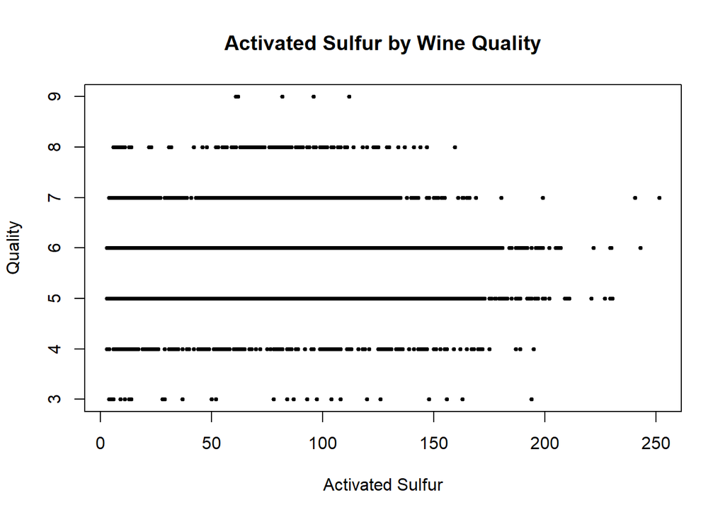

```r
plot(Wine$total.free, Wine$quality, col = 'Black', pch = 19, cex = .5, xlab = 'Activated Sulfur', ylab = 'Quality', main = 'Activated Sulfur by Wine Quality')
```

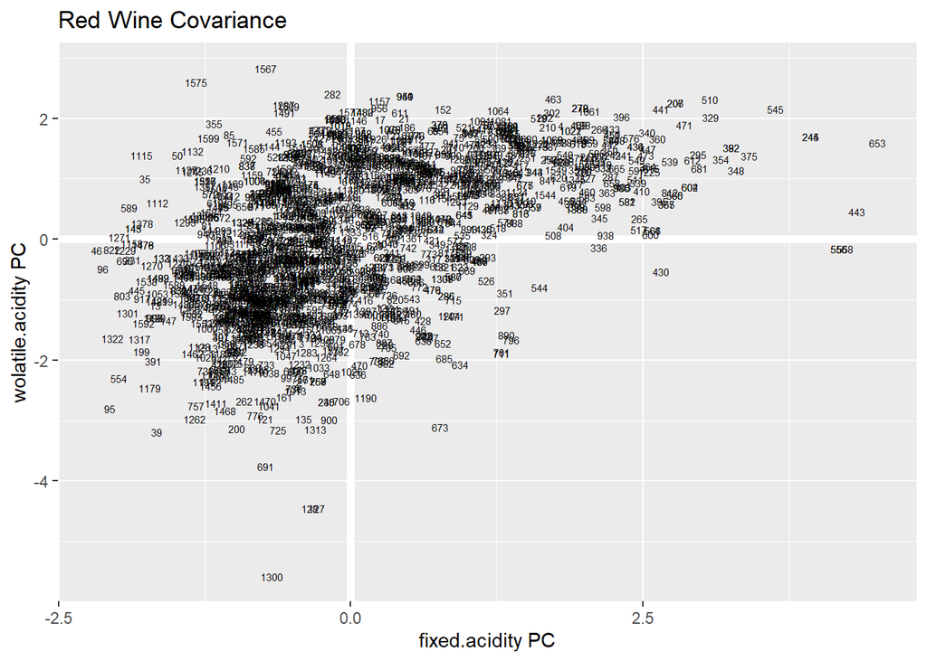

```r
ggplot(rW.CV.PCS, aes(rw.V.PC1, rw.V.PC2)) +
    modelr::geom_ref_line(h = 0) +
    modelr::geom_ref_line(v = 0) +
    geom_text(aes(label = RWCOV.index), size = 2) +
    xlab("fixed.acidity PC") +
    ylab("wolatile.acidity PC") +
    ggtitle("Red Wine Covariance")
```

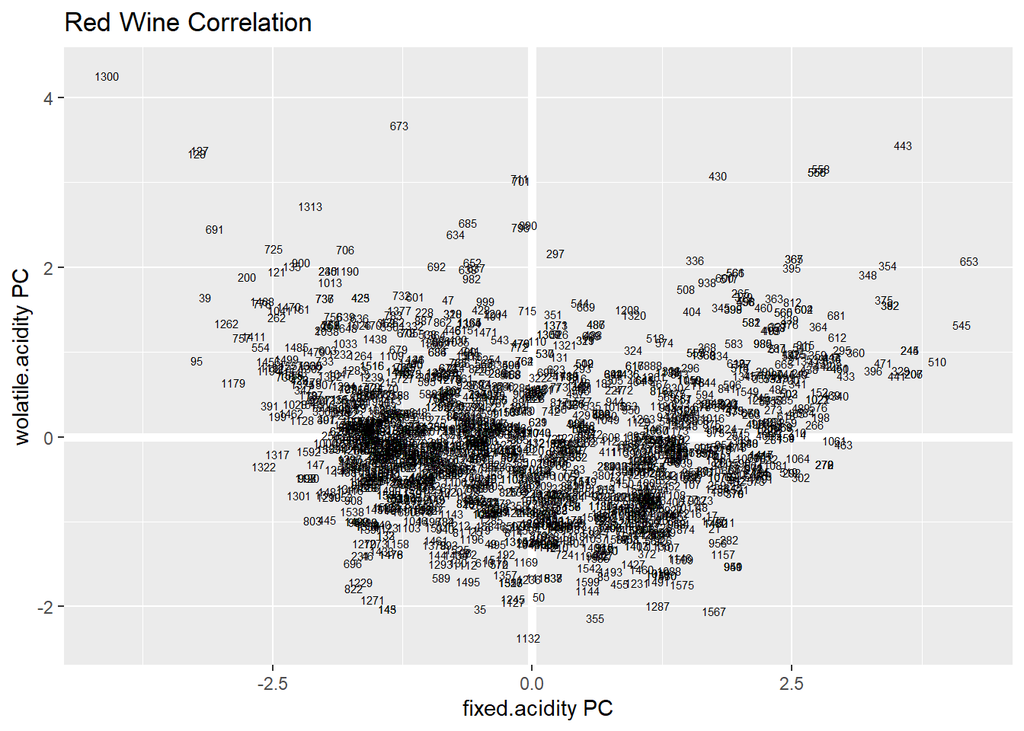

```r
ggplot(rW.CR.PCS, aes(rw.R.PC1, rw.R.PC2)) +
    modelr::geom_ref_line(h = 0) +
    modelr::geom_ref_line(v = 0) +
    geom_text(aes(label = RWCOR.index), size = 2) +
    xlab("fixed.acidity PC") +
    ylab("wolatile.acidity PC") +
    ggtitle("Red Wine Correlation")
```

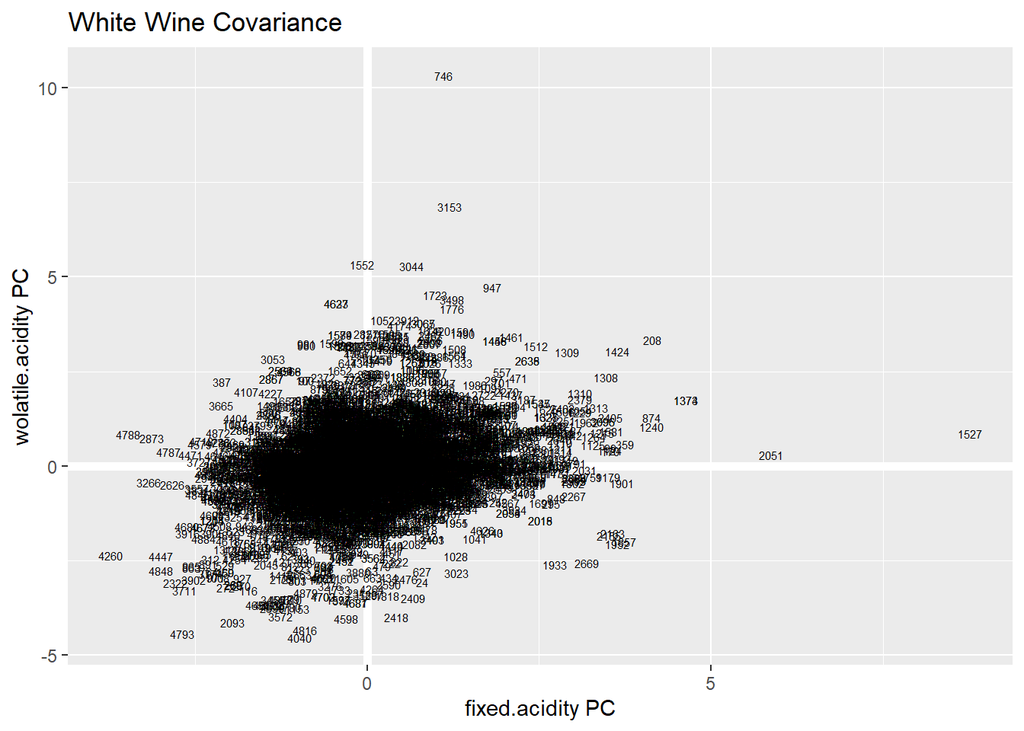

```r
ggplot(wW.CV.PCS, aes(ww.V.PC1, ww.V.PC2)) +
    modelr::geom_ref_line(h = 0) +
    modelr::geom_ref_line(v = 0) +
    geom_text(aes(label = WWCOV.index), size = 2) +
    xlab("fixed.acidity PC") +
    ylab("wolatile.acidity PC") +
    ggtitle("White Wine Covariance")
```

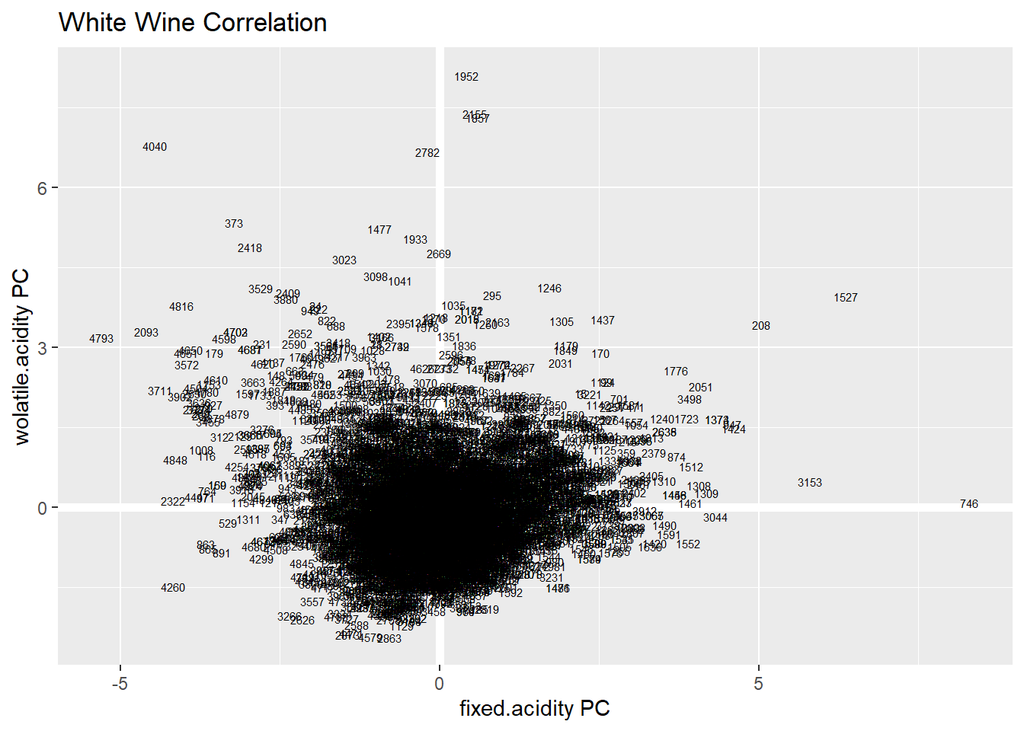

```r
ggplot(wW.CR.PCS, aes(ww.R.PC1, ww.R.PC2)) +
    modelr::geom_ref_line(h = 0) +
    modelr::geom_ref_line(v = 0) +
    geom_text(aes(label = WWCOR.index), size = 2) +
    xlab("fixed.acidity PC") +
    ylab("wolatile.acidity PC") +
    ggtitle("White Wine Correlation")
```

### Unused Models:

```r
redWineModel <- lm(quality ~ fixed.acidity + volatile.acidity + citric.acid + residual.sugar + chlorides + free.sulfur.dioxide + total.sulfur.dioxide + pH + sulphates + alcohol, data = redWine) # All variables contributing
summary(redWineModel)
```

```
##
## Call:
## lm(formula = quality ~ fixed.acidity + volatile.acidity + citric.acid +
##     residual.sugar + chlorides + free.sulfur.dioxide + total.sulfur.dioxide +
##     pH + sulphates + alcohol, data = redWine)
##
## Residuals:
##      Min       1Q   Median       3Q      Max
## -2.70097 -0.36494 -0.05077  0.45202  2.06761
##
## Coefficients:
##                        Estimate Std. Error t value Pr(>|t|)
## (Intercept)           4.3971586  0.6117866   7.187 1.01e-12 ***
## fixed.acidity         0.0100411  0.0160430   0.626  0.53148
## volatile.acidity     -1.0804709  0.1199984  -9.004  < 2e-16 ***
## citric.acid          -0.1851050  0.1468806  -1.260  0.20777
## residual.sugar        0.0056773  0.0120871   0.470  0.63863
## chlorides            -1.8934329  0.4166441  -4.544 5.92e-06 ***
## free.sulfur.dioxide   0.0054009  0.0021829   2.474  0.01346 *
## total.sulfur.dioxide -0.0038717  0.0007527  -5.144 3.02e-07 ***
## pH                   -0.4748918  0.1571652  -3.022  0.00255 **
## sulphates             0.9123442  0.1107711   8.236 3.67e-16 ***
## alcohol               0.2870002  0.0174328  16.463  < 2e-16 ***
## ---
## Signif. codes:  0 '***' 0.001 '**' 0.01 '*' 0.05 '.' 0.1 ' ' 1
##
## Residual standard error: 0.6467 on 1586 degrees of freedom
## Multiple R-squared:  0.3612, Adjusted R-squared:  0.3571
## F-statistic: 89.67 on 10 and 1586 DF,  p-value: < 2.2e-16
```

```r
whiteWineModel <- lm(quality ~ fixed.acidity + volatile.acidity + citric.acid + residual.sugar + chlorides + free.sulfur.dioxide + total.sulfur.dioxide + pH + sulphates + alcohol, data = whiteWine) # All variables contributing
summary(whiteWineModel)
```

```
##
## Call:
## lm(formula = quality ~ fixed.acidity + volatile.acidity + citric.acid +
##     residual.sugar + chlorides + free.sulfur.dioxide + total.sulfur.dioxide +
##     pH + sulphates + alcohol, data = whiteWine)
##
## Residuals:
##     Min      1Q  Median      3Q     Max
## -3.4682 -0.6245 -0.0068  0.4786  3.2136
##
## Coefficients:
##                        Estimate Std. Error t value Pr(>|t|)
## (Intercept)           6.3314392  0.3524467  17.964  < 2e-16 ***
## fixed.acidity        -0.0763859  0.0163439  -4.674 3.04e-06 ***
## volatile.acidity      3.6570670 13.3311630   0.274  0.78385
## citric.acid           0.1784958  0.1052454   1.696  0.08995 .
## residual.sugar       -0.0042736  0.0026418  -1.618  0.10580
## chlorides            -6.9258525  0.5601926 -12.363  < 2e-16 ***
## free.sulfur.dioxide   0.0082838  0.0009443   8.773  < 2e-16 ***
## total.sulfur.dioxide -0.0043574  0.0003941 -11.057  < 2e-16 ***
## pH                    0.2427462  0.0906139   2.679  0.00741 **
## sulphates             0.4780886  0.1068519   4.474 7.84e-06 ***
## alcohol              -4.8824727 13.3264427  -0.366  0.71410
## ---
## Signif. codes:  0 '***' 0.001 '**' 0.01 '*' 0.05 '.' 0.1 ' ' 1
##
## Residual standard error: 0.8293 on 4882 degrees of freedom
## Multiple R-squared:  0.1191, Adjusted R-squared:  0.1173
## F-statistic: 66.03 on 10 and 4882 DF,  p-value: < 2.2e-16
```

## References

Data Set: https://archive.ics.uci.edu/ml/machine-learning-databases/wine-quality/

Paper: https://www.sciencedirect.com/science/article/abs/pii/S0167923609001377?via%3Dihub

P. Cortez, A. Cerdeira, F. Almeida, T. Matos and J. Reis. Modeling wine preferences by data mining from physicochemical properties. In Decision Support Systems, Elsevier, 47(4):547-553, 2009.